# Practical Machine Learning Project

Shadi

5/14/2020

## Summary

We start our analysis loading the reaquired package and libraries and continue with reading the train and test data

```r
library(rpart)
library(rpart.plot)
library(RColorBrewer)
library(rattle)
library(randomForest)
library(caret)
library(KernSmooth)
library(Hmisc)
library(foreach)
library(doParallel)
```

```r
set.seed(4356)
setwd("~/Desktop/test/data")
train<-read.csv(file="pml-training.csv" , sep ="," )
validation<-read.csv(file="pml-testing.csv",sep =",")
```

Our data are cleaned and ready for the analysis, but before starting the analysis we need a validation data set since are data set is large enough to have a validation an test data set. I’ll use cross validation within the training partition to improve the model fit and then do an out-of-sample test with the testing partition.

```r
set.seed(127)
training_sample <- createDataPartition(y=train$classe, p=0.7, list=FALSE)
training <- train[training_sample, ]
testing <- train[-training_sample, ]
```

Since we aim to do in sample and out sample prediction and check the errors the NA variable are of importance, so first we check the porportion of column with NA and then if we encounter NA then we remove those Columnes with NA

```r
NAs <- colMeans(is.na(training))
table(NAs)
```

```
## NAs
##                 0 0.978233966659387
##                93                67
```

```r
all_zero_colnames <- sapply(names(validation), function(x) all(is.na(validation[,x])==TRUE))
nznames <- names(all_zero_colnames)[all_zero_colnames==FALSE]
nznames <- nznames[-(1:7)]
nznames <- nznames[1:(length(nznames)-1)]
```

Now that we removed missing values, We are ready for Model building, I start with predicting with the tree but it dosen’t seems a good model for perdiction.

```r
fitControl <- trainControl(method='cv', number = 3)
modFit_tree <- train(classe ~ ., data=training[, c('classe', nznames)],trControl=fitControl, method='rpart')
save(modFit_tree, file='./modFit_tree.RData')

print(modFit_tree$finalModel)
```

```
## n= 13737
##
## node), split, n, loss, yval, (yprob)
##       * denotes terminal node
##
##  1) root 13737 9831 A (0.28 0.19 0.17 0.16 0.18)
##    2) roll_belt< 130.5 12572 8676 A (0.31 0.21 0.19 0.18 0.11)
##      4) pitch_forearm< -33.55 1143   12 A (0.99 0.01 0 0 0) *
##      5) pitch_forearm>=-33.55 11429 8664 A (0.24 0.23 0.21 0.2 0.12)
##       10) magnet_dumbbell_y< 439.5 9680 6973 A (0.28 0.18 0.24 0.19 0.11)
##         20) roll_forearm< 123.5 5996 3561 A (0.41 0.18 0.19 0.17 0.059) *
##         21) roll_forearm>=123.5 3684 2480 C (0.074 0.18 0.33 0.23 0.19) *
##       11) magnet_dumbbell_y>=439.5 1749  851 B (0.033 0.51 0.046 0.22 0.19) *
##    3) roll_belt>=130.5 1165   10 E (0.0086 0 0 0 0.99) *
```

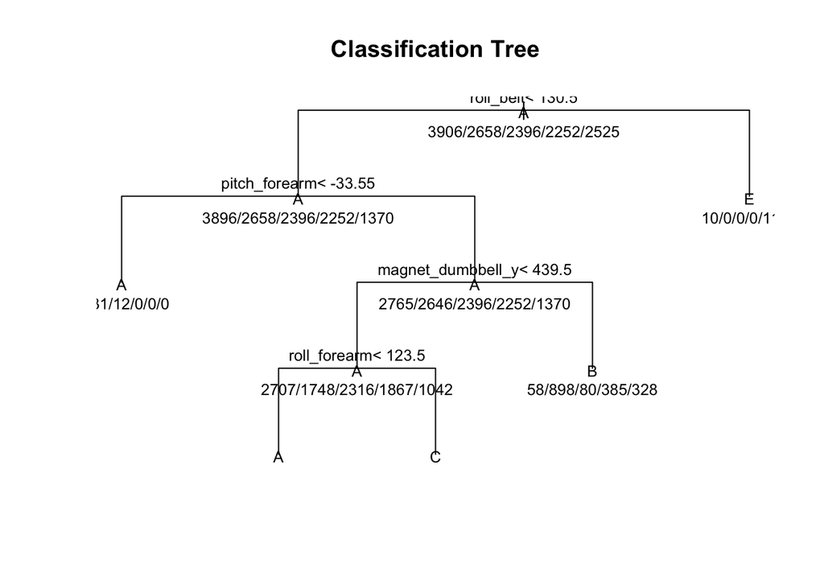

```r
plot(modFit_tree$finalModel, uniform=TRUE,
      main="Classification Tree")
text(modFit_tree$finalModel, use.n=TRUE, all=TRUE, cex=.8)
```

Therefore, instead of moving to error test I will fit a random forest model. since they are usually giving the most acurate predictions.

```r
set.seed(10)
fitControl <- trainControl(method='cv', number = 3)

modFit_RF <-  train(
  classe ~ ., data=training[, c('classe', nznames)],trControl=fitControl, method='rf', ntree=100)
save(modFit_RF, file='./modFit_RF.RData')
```

now it’s time to check the prediciton of the model and it accuracy on the validation set

```r
pred <- predict(modFit_RF, newdata = testing)

confusionMatrix(pred, testing$classe)
```

```
## Confusion Matrix and Statistics
##
##           Reference
## Prediction    A    B    C    D    E
##          A 1673    4    0    1    0
##          B    1 1133    1    0    1
##          C    0    2 1023   13    0
##          D    0    0    2  950    5
##          E    0    0    0    0 1076
##
## Overall Statistics
##
##                Accuracy : 0.9949
##                  95% CI : (0.9927, 0.9966)
##     No Information Rate : 0.2845
##     P-Value [Acc > NIR] : < 2.2e-16
##
##                   Kappa : 0.9936
##
##  Mcnemar's Test P-Value : NA
##
## Statistics by Class:
##
##                      Class: A Class: B Class: C Class: D Class: E
## Sensitivity            0.9994   0.9947   0.9971   0.9855   0.9945
## Specificity            0.9988   0.9994   0.9969   0.9986   1.0000
## Pos Pred Value         0.9970   0.9974   0.9855   0.9927   1.0000
## Neg Pred Value         0.9998   0.9987   0.9994   0.9972   0.9988
## Prevalence             0.2845   0.1935   0.1743   0.1638   0.1839
## Detection Rate         0.2843   0.1925   0.1738   0.1614   0.1828
## Detection Prevalence   0.2851   0.1930   0.1764   0.1626   0.1828
## Balanced Accuracy      0.9991   0.9971   0.9970   0.9920   0.9972
```

Finally, it is time to use our model for prediciton

```r
predValidation <- predict(modFit_RF, newdata=validation)
ValidationPredictionResults <- data.frame(
  problem_id=validation$problem_id,
  predicted=predValidation
)
print(ValidationPredictionResults)
```

```
##    problem_id predicted
## 1           1         B
## 2           2         A
## 3           3         B
## 4           4         A
## 5           5         A
## 6           6         E
## 7           7         D
## 8           8         B
## 9           9         A
## 10         10         A
## 11         11         B
## 12         12         C
## 13         13         B
## 14         14         A
## 15         15         E
## 16         16         E
## 17         17         A
## 18         18         B
## 19         19         B
## 20         20         B
```